# Housing Price Prediction

```
Nikhil N Barigidad
```

**Predict Actual Value of the Prospective Properties**

A US-based housing company named Surprise Housing has decided to enter the Australian market. The company uses data analytics to purchase houses at a price below their actual values and flip them on at a higher price

The company is looking at prospective properties to buy to enter the market. You are required to build a regression model using regularisation in order to predict the actual value of the prospective properties and decide whether to invest in them or not.

The company wants to know:

- Which variables are significant in predicting the price of a house, and
- How well those variables describe the price of a house.

### 1. Data Understanding and Exploration

```python
import pandas as pd
import numpy as np

import matplotlib.pyplot as plt
import seaborn as sns

import warnings
warnings.filterwarnings('ignore')
```

```python
housingData = pd.read_csv("train.csv")
housingData.head()
```

|  | Id | MSSubClass | MSZoning | LotFrontage | LotArea | Street | Alley | LotShape | LandContour | Utilities | ... | PoolArea | PoolQC | Fence | MiscFeature | MiscVal | MoSold | YrSold | SaleType | SaleCondition | SalePrice |
| --- | --- | --- | --- | --- | --- | --- | --- | --- | --- | --- | --- | --- | --- | --- | --- | --- | --- | --- | --- | --- | --- |
| 0 | 1 | 60 | RL | 65.0 | 8450 | Pave | NaN | Reg | Lvl | AllPub | ... | 0 | NaN | NaN | NaN | 0 | 2 | 2008 | WD | Normal | 208500 |
| 1 | 2 | 20 | RL | 80.0 | 9600 | Pave | NaN | Reg | Lvl | AllPub | ... | 0 | NaN | NaN | NaN | 0 | 5 | 2007 | WD | Normal | 181500 |
| 2 | 3 | 60 | RL | 68.0 | 11250 | Pave | NaN | IR1 | Lvl | AllPub | ... | 0 | NaN | NaN | NaN | 0 | 9 | 2008 | WD | Normal | 223500 |
| 3 | 4 | 70 | RL | 60.0 | 9550 | Pave | NaN | IR1 | Lvl | AllPub | ... | 0 | NaN | NaN | NaN | 0 | 2 | 2006 | WD | Abnorml | 140000 |
| 4 | 5 | 60 | RL | 84.0 | 14260 | Pave | NaN | IR1 | Lvl | AllPub | ... | 0 | NaN | NaN | NaN | 0 | 12 | 2008 | WD | Normal | 250000 |

5 rows × 81 columns

```python
housingData.info()
```

```
<class 'pandas.core.frame.DataFrame'>
RangeIndex: 1460 entries, 0 to 1459
Data columns (total 81 columns):
 #   Column         Non-Null Count  Dtype
---  ------         --------------  -----
 0   Id             1460 non-null   int64
 1   MSSubClass     1460 non-null   int64
 2   MSZoning       1460 non-null   object
 3   LotFrontage    1201 non-null   float64
 4   LotArea        1460 non-null   int64
 5   Street         1460 non-null   object
 6   Alley          91 non-null     object
 7   LotShape       1460 non-null   object
 8   LandContour    1460 non-null   object
 9   Utilities      1460 non-null   object
```

[output cut: 73 more lines]

### Missing values Treatment

```python
#Finding missing categorical values
datanaObj = pd.DataFrame(housingData.select_dtypes(include='object').isnull().sum()[housingData.select_dtypes(
    include='object').isnull().sum()>0], columns={"naPercentage"})
datanaObj
```

|  | naPercentage |
| --- | --- |
| Alley | 1369 |
| MasVnrType | 8 |
| BsmtQual | 37 |
| BsmtCond | 37 |
| BsmtExposure | 38 |
| BsmtFinType1 | 37 |
| BsmtFinType2 | 38 |
| Electrical | 1 |
| FireplaceQu | 690 |
| GarageType | 81 |
| GarageFinish | 81 |
| GarageQual | 81 |
| GarageCond | 81 |
| PoolQC | 1453 |
| Fence | 1179 |
| MiscFeature | 1406 |

- There are total 16 categorical columns with missing values

```python
#Filling 'na' values with 'None'
for column in datanaObj.index:
    housingData[column] = housingData[column].fillna('None')
```

```python
#Finding missing values of type int64 and float64
datana_num = pd.DataFrame(housingData.select_dtypes(include=['int', 'float']
                                                   ).isnull().sum()[housingData.select_dtypes(
    include=['int64', 'float64']).isnull().sum()>0], columns={"naPercentage"})
datana_num
```

|  | naPercentage |
| --- | --- |
| LotFrontage | 259 |
| MasVnrArea | 8 |
| GarageYrBlt | 81 |

- 3 columns of type int64, float64 has missing values

```python
numCols = ['LotFrontage', 'MasVnrArea', 'GarageYrBlt']
for col in numCols:
    housingData[col] = housingData[col].fillna(housingData[col].median())
```

```python
#columns with same value repeated over 85% of the data will probably be skewed thus dropping such columns
colsTbD = []
num_cols = housingData.select_dtypes(include=['int64', 'float64', 'object'])
for col in (num_cols):
    if(housingData[col].value_counts().max() > housingData.shape[0]*0.85):
        colsTbD.append(col)

housingData.drop(colsTbD, axis=1, inplace=True)
housingData.head()
```

|  | Id | MSSubClass | MSZoning | LotFrontage | LotArea | LotShape | LotConfig | Neighborhood | BldgType | HouseStyle | ... | GarageFinish | GarageCars | GarageArea | WoodDeckSF | OpenPorchSF | Fence | MoSold | YrSold | SaleCondition | SalePrice |
| --- | --- | --- | --- | --- | --- | --- | --- | --- | --- | --- | --- | --- | --- | --- | --- | --- | --- | --- | --- | --- | --- |
| 0 | 1 | 60 | RL | 65.0 | 8450 | Reg | Inside | CollgCr | 1Fam | 2Story | ... | RFn | 2 | 548 | 0 | 61 | None | 2 | 2008 | Normal | 208500 |
| 1 | 2 | 20 | RL | 80.0 | 9600 | Reg | FR2 | Veenker | 1Fam | 1Story | ... | RFn | 2 | 460 | 298 | 0 | None | 5 | 2007 | Normal | 181500 |
| 2 | 3 | 60 | RL | 68.0 | 11250 | IR1 | Inside | CollgCr | 1Fam | 2Story | ... | RFn | 2 | 608 | 0 | 42 | None | 9 | 2008 | Normal | 223500 |
| 3 | 4 | 70 | RL | 60.0 | 9550 | IR1 | Corner | Crawfor | 1Fam | 2Story | ... | Unf | 3 | 642 | 0 | 35 | None | 2 | 2006 | Abnorml | 140000 |
| 4 | 5 | 60 | RL | 84.0 | 14260 | IR1 | FR2 | NoRidge | 1Fam | 2Story | ... | RFn | 3 | 836 | 192 | 84 | None | 12 | 2008 | Normal | 250000 |

5 rows × 51 columns

```python
#MoSold also doesn't seem very important
housingData.drop('MoSold', axis=1, inplace=True)
```

### New columns

```python
#Column to check whether the house is remodelled or not
def isRemodelled(row):
    if (row['YearBuilt'] == row['YearRemodAdd']):
        return 0
    elif (row['YearBuilt'] < row['YearRemodAdd']):
        return 1
    else:
        return 2

housingData['isRemodelled'] = housingData.apply(isRemodelled, axis=1)
housingData.head()
```

|  | Id | MSSubClass | MSZoning | LotFrontage | LotArea | LotShape | LotConfig | Neighborhood | BldgType | HouseStyle | ... | GarageFinish | GarageCars | GarageArea | WoodDeckSF | OpenPorchSF | Fence | YrSold | SaleCondition | SalePrice | isRemodelled |
| --- | --- | --- | --- | --- | --- | --- | --- | --- | --- | --- | --- | --- | --- | --- | --- | --- | --- | --- | --- | --- | --- |
| 0 | 1 | 60 | RL | 65.0 | 8450 | Reg | Inside | CollgCr | 1Fam | 2Story | ... | RFn | 2 | 548 | 0 | 61 | None | 2008 | Normal | 208500 | 0 |
| 1 | 2 | 20 | RL | 80.0 | 9600 | Reg | FR2 | Veenker | 1Fam | 1Story | ... | RFn | 2 | 460 | 298 | 0 | None | 2007 | Normal | 181500 | 0 |
| 2 | 3 | 60 | RL | 68.0 | 11250 | IR1 | Inside | CollgCr | 1Fam | 2Story | ... | RFn | 2 | 608 | 0 | 42 | None | 2008 | Normal | 223500 | 1 |
| 3 | 4 | 70 | RL | 60.0 | 9550 | IR1 | Corner | Crawfor | 1Fam | 2Story | ... | Unf | 3 | 642 | 0 | 35 | None | 2006 | Abnorml | 140000 | 1 |
| 4 | 5 | 60 | RL | 84.0 | 14260 | IR1 | FR2 | NoRidge | 1Fam | 2Story | ... | RFn | 3 | 836 | 192 | 84 | None | 2008 | Normal | 250000 | 0 |

5 rows × 51 columns

```python
#Lets find out age of the house remodelled
def remodelledAge(row):
    if(row['YearBuilt'] == row['YearRemodAdd']):
        return row['YrSold'] - row['YearBuilt']
    else:
        return row['YrSold'] - row['YearRemodAdd']
housingData['BuiltOrRemAge'] = housingData.apply(remodelledAge, axis=1)
housingData.head()
```

|  | Id | MSSubClass | MSZoning | LotFrontage | LotArea | LotShape | LotConfig | Neighborhood | BldgType | HouseStyle | ... | GarageCars | GarageArea | WoodDeckSF | OpenPorchSF | Fence | YrSold | SaleCondition | SalePrice | isRemodelled | BuiltOrRemAge |
| --- | --- | --- | --- | --- | --- | --- | --- | --- | --- | --- | --- | --- | --- | --- | --- | --- | --- | --- | --- | --- | --- |
| 0 | 1 | 60 | RL | 65.0 | 8450 | Reg | Inside | CollgCr | 1Fam | 2Story | ... | 2 | 548 | 0 | 61 | None | 2008 | Normal | 208500 | 0 | 5 |
| 1 | 2 | 20 | RL | 80.0 | 9600 | Reg | FR2 | Veenker | 1Fam | 1Story | ... | 2 | 460 | 298 | 0 | None | 2007 | Normal | 181500 | 0 | 31 |
| 2 | 3 | 60 | RL | 68.0 | 11250 | IR1 | Inside | CollgCr | 1Fam | 2Story | ... | 2 | 608 | 0 | 42 | None | 2008 | Normal | 223500 | 1 | 6 |
| 3 | 4 | 70 | RL | 60.0 | 9550 | IR1 | Corner | Crawfor | 1Fam | 2Story | ... | 3 | 642 | 0 | 35 | None | 2006 | Abnorml | 140000 | 1 | 36 |
| 4 | 5 | 60 | RL | 84.0 | 14260 | IR1 | FR2 | NoRidge | 1Fam | 2Story | ... | 3 | 836 | 192 | 84 | None | 2008 | Normal | 250000 | 0 | 8 |

5 rows × 52 columns

```python
#Oldest garage was built in 1900s and the newest is in 2010,
#Garages built in and after 2000 will be consider as new and before 2000 will be old
#new=1, old=0

def newGarage(row):
    if(row['GarageYrBlt'] >= 2000):
        return 1
    else:
        return 0
housingData['newGarage'] = housingData.apply(newGarage, axis=1)
housingData.head()
```

|  | Id | MSSubClass | MSZoning | LotFrontage | LotArea | LotShape | LotConfig | Neighborhood | BldgType | HouseStyle | ... | GarageArea | WoodDeckSF | OpenPorchSF | Fence | YrSold | SaleCondition | SalePrice | isRemodelled | BuiltOrRemAge | newGarage |
| --- | --- | --- | --- | --- | --- | --- | --- | --- | --- | --- | --- | --- | --- | --- | --- | --- | --- | --- | --- | --- | --- |
| 0 | 1 | 60 | RL | 65.0 | 8450 | Reg | Inside | CollgCr | 1Fam | 2Story | ... | 548 | 0 | 61 | None | 2008 | Normal | 208500 | 0 | 5 | 1 |
| 1 | 2 | 20 | RL | 80.0 | 9600 | Reg | FR2 | Veenker | 1Fam | 1Story | ... | 460 | 298 | 0 | None | 2007 | Normal | 181500 | 0 | 31 | 0 |
| 2 | 3 | 60 | RL | 68.0 | 11250 | IR1 | Inside | CollgCr | 1Fam | 2Story | ... | 608 | 0 | 42 | None | 2008 | Normal | 223500 | 1 | 6 | 1 |
| 3 | 4 | 70 | RL | 60.0 | 9550 | IR1 | Corner | Crawfor | 1Fam | 2Story | ... | 642 | 0 | 35 | None | 2006 | Abnorml | 140000 | 1 | 36 | 0 |
| 4 | 5 | 60 | RL | 84.0 | 14260 | IR1 | FR2 | NoRidge | 1Fam | 2Story | ... | 836 | 192 | 84 | None | 2008 | Normal | 250000 | 0 | 8 | 1 |

5 rows × 53 columns

```python
housingData.drop(['YearBuilt', 'YearRemodAdd', 'YrSold', 'GarageYrBlt'], axis=1, inplace=True)
```

```python
datana = pd.DataFrame(housingData.isna().sum()/housingData.shape[0], columns={"naPercentage"})
datana[datana['naPercentage'] > 0]
```

|  | naPercentage |
| --- | --- |

`No missing values in dataset`

```python
#Checking for duplicates
housingData[housingData.duplicated(['Id'])]
```

|  | Id | MSSubClass | MSZoning | LotFrontage | LotArea | LotShape | LotConfig | Neighborhood | BldgType | HouseStyle | ... | GarageCars | GarageArea | WoodDeckSF | OpenPorchSF | Fence | SaleCondition | SalePrice | isRemodelled | BuiltOrRemAge | newGarage |
| --- | --- | --- | --- | --- | --- | --- | --- | --- | --- | --- | --- | --- | --- | --- | --- | --- | --- | --- | --- | --- | --- |

0 rows × 49 columns

`No duplicates present in data`

```python
#Drop id since it is just index
housingData.drop(['Id'], axis=1, inplace=True)
```

### Outlier Treatment

```python
housingData.describe(percentiles=[0.25,0.50,0.75,0.95,0.99])
```

|  | MSSubClass | LotFrontage | LotArea | OverallQual | OverallCond | MasVnrArea | BsmtFinSF1 | BsmtUnfSF | TotalBsmtSF | 1stFlrSF | ... | TotRmsAbvGrd | Fireplaces | GarageCars | GarageArea | WoodDeckSF | OpenPorchSF | SalePrice | isRemodelled | BuiltOrRemAge | newGarage |
| --- | --- | --- | --- | --- | --- | --- | --- | --- | --- | --- | --- | --- | --- | --- | --- | --- | --- | --- | --- | --- | --- |
| count | 1460.000000 | 1460.000000 | 1460.000000 | 1460.000000 | 1460.000000 | 1460.000000 | 1460.000000 | 1460.000000 | 1460.000000 | 1460.000000 | ... | 1460.000000 | 1460.000000 | 1460.000000 | 1460.000000 | 1460.000000 | 1460.000000 | 1460.000000 | 1460.000000 | 1460.000000 | 1460.000000 |
| mean | 56.897260 | 69.863699 | 10516.828082 | 6.099315 | 5.575342 | 103.117123 | 443.639726 | 567.240411 | 1057.429452 | 1162.626712 | ... | 6.517808 | 0.613014 | 1.767123 | 472.980137 | 94.244521 | 46.660274 | 180921.195890 | 0.476712 | 22.950000 | 0.275342 |
| std | 42.300571 | 22.027677 | 9981.264932 | 1.382997 | 1.112799 | 180.731373 | 456.098091 | 441.866955 | 438.705324 | 386.587738 | ... | 1.625393 | 0.644666 | 0.747315 | 213.804841 | 125.338794 | 66.256028 | 79442.502883 | 0.499629 | 20.640653 | 0.446840 |
| min | 20.000000 | 21.000000 | 1300.000000 | 1.000000 | 1.000000 | 0.000000 | 0.000000 | 0.000000 | 0.000000 | 334.000000 | ... | 2.000000 | 0.000000 | 0.000000 | 0.000000 | 0.000000 | 0.000000 | 34900.000000 | 0.000000 | -1.000000 | 0.000000 |
| 25% | 20.000000 | 60.000000 | 7553.500000 | 5.000000 | 5.000000 | 0.000000 | 0.000000 | 223.000000 | 795.750000 | 882.000000 | ... | 5.000000 | 0.000000 | 1.000000 | 334.500000 | 0.000000 | 0.000000 | 129975.000000 | 0.000000 | 4.000000 | 0.000000 |
| 50% | 50.000000 | 69.000000 | 9478.500000 | 6.000000 | 5.000000 | 0.000000 | 383.500000 | 477.500000 | 991.500000 | 1087.000000 | ... | 6.000000 | 1.000000 | 2.000000 | 480.000000 | 0.000000 | 25.000000 | 163000.000000 | 0.000000 | 14.000000 | 0.000000 |
| 75% | 70.000000 | 79.000000 | 11601.500000 | 7.000000 | 6.000000 | 164.250000 | 712.250000 | 808.000000 | 1298.250000 | 1391.250000 | ... | 7.000000 | 1.000000 | 2.000000 | 576.000000 | 168.000000 | 68.000000 | 214000.000000 | 1.000000 | 41.000000 | 1.000000 |
| 95% | 160.000000 | 104.000000 | 17401.150000 | 8.000000 | 8.000000 | 456.000000 | 1274.000000 | 1468.000000 | 1753.000000 | 1831.250000 | ... | 10.000000 | 2.000000 | 3.000000 | 850.100000 | 335.000000 | 175.050000 | 326100.000000 | 1.000000 | 58.000000 | 1.000000 |
| 99% | 190.000000 | 137.410000 | 37567.640000 | 10.000000 | 9.000000 | 791.280000 | 1572.410000 | 1797.050000 | 2155.050000 | 2219.460000 | ... | 11.000000 | 2.000000 | 3.000000 | 1002.790000 | 505.460000 | 285.820000 | 442567.010000 | 1.000000 | 60.000000 | 1.000000 |
| max | 190.000000 | 313.000000 | 215245.000000 | 10.000000 | 9.000000 | 1600.000000 | 5644.000000 | 2336.000000 | 6110.000000 | 4692.000000 | ... | 14.000000 | 3.000000 | 4.000000 | 1418.000000 | 857.000000 | 547.000000 | 755000.000000 | 1.000000 | 60.000000 | 1.000000 |

10 rows × 26 columns

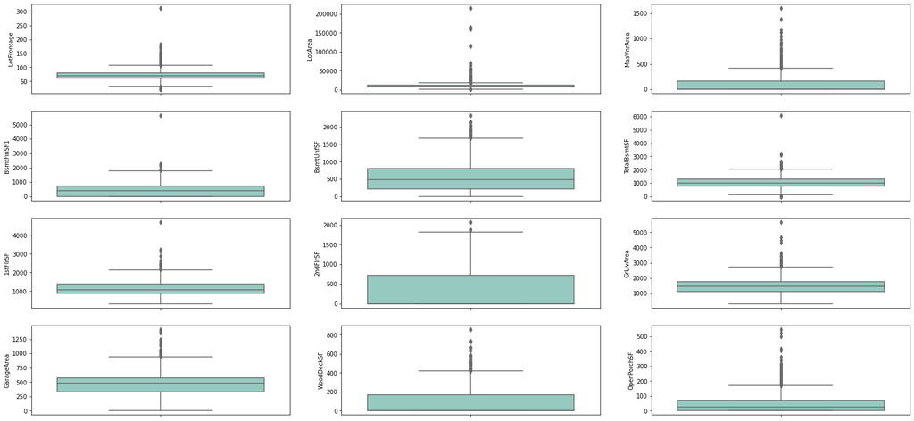

```python
#Visualising outliers using boxplot of all numeric columns

numColsBP = ['LotFrontage', 'LotArea', 'MasVnrArea', 'BsmtFinSF1', 'BsmtUnfSF', 'TotalBsmtSF', '1stFlrSF', '2ndFlrSF',
             'GrLivArea', 'GarageArea', 'WoodDeckSF', 'OpenPorchSF']

plt.figure(figsize=(27,40))
for i in range(12):
    plt.subplot(12,3,i+1)
    sns.boxplot(y=numColsBP[i], palette='Set3', data=housingData)
```

```python
#Removing values that are beyond 99%

for col in numColsBP:
    housingData = housingData[housingData[col] < housingData[col].quantile(0.99)]
```

```python
#Data Retailned at the end of cleaning
print(round(len(housingData)/1460,2))
```

```
0.88
```

> *88%* of the data was retained after the cleaning

```python
housingData.dtypes
```

```
MSSubClass         int64
MSZoning          object
LotFrontage      float64
LotArea            int64
LotShape          object
LotConfig         object
Neighborhood      object
BldgType          object
HouseStyle        object
OverallQual        int64
OverallCond        int64
RoofStyle         object
Exterior1st       object
Exterior2nd       object
MasVnrType        object
MasVnrArea       float64
ExterQual         object
Foundation        object
BsmtQual          object
BsmtExposure      object
BsmtFinType1      object
BsmtFinSF1         int64
BsmtUnfSF          int64
TotalBsmtSF        int64
HeatingQC         object
1stFlrSF           int64
2ndFlrSF           int64
GrLivArea          int64
BsmtFullBath       int64
FullBath           int64
HalfBath           int64
BedroomAbvGr       int64
KitchenQual       object
TotRmsAbvGrd       int64
Fireplaces         int64
FireplaceQu       object
GarageType        object
GarageFinish      object
GarageCars         int64
GarageArea         int64
WoodDeckSF         int64
OpenPorchSF        int64
Fence             object
SaleCondition     object
SalePrice          int64
isRemodelled       int64
BuiltOrRemAge      int64
newGarage          int64
dtype: object
```

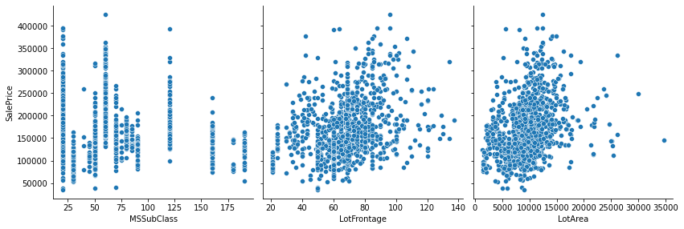

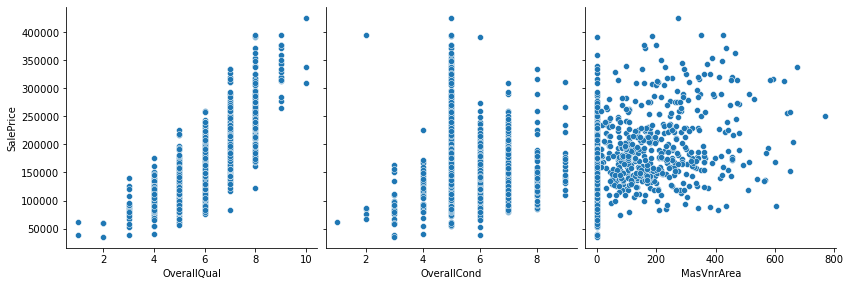

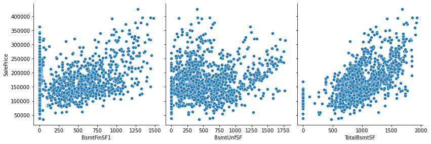

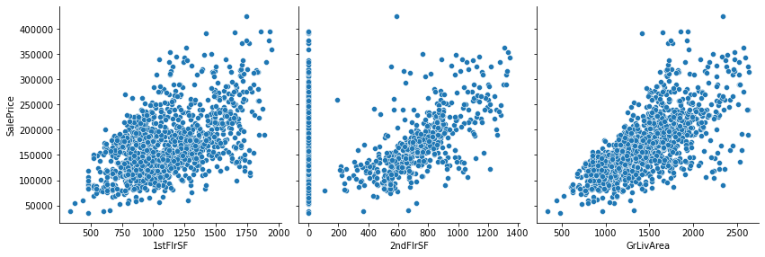

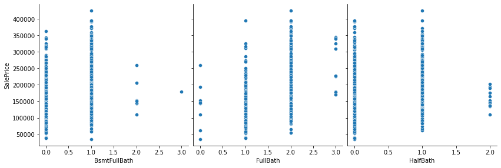

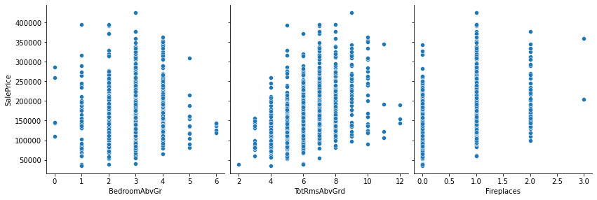

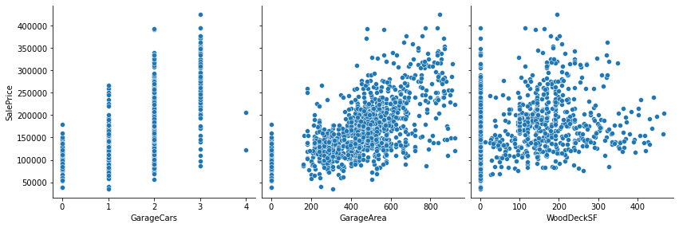

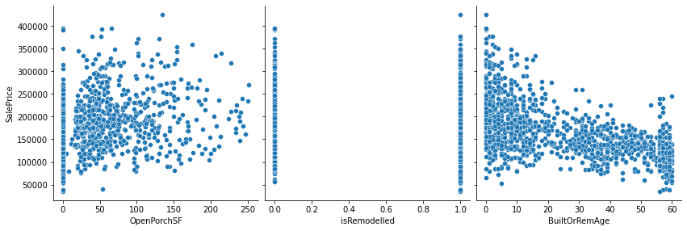

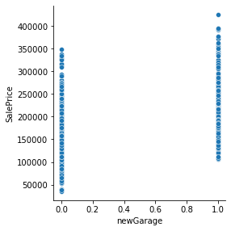

```python
#Scatter plot for all numerical variables
numcolsSP = list(housingData.select_dtypes(include=['int64', 'float64']).columns)
numcolsSP.remove('SalePrice')

plt.figure(figsize=(40,60))
for i in range(0,len(numcolsSP)-1,3):
    sns.pairplot(housingData, x_vars=[numcolsSP[i], numcolsSP[i+1], numcolsSP[i+2]],
                 y_vars='SalePrice', height=4, aspect=1, kind='scatter')
sns.pairplot(housingData, x_vars=numcolsSP[-1], y_vars='SalePrice', height=4, aspect=1, kind='scatter')
plt.show()
```

**Inferences**

- Most of the features are cluttered on the left and are scattered towards right
- BuiltOrRemAge show negative correlation which is also practically correct

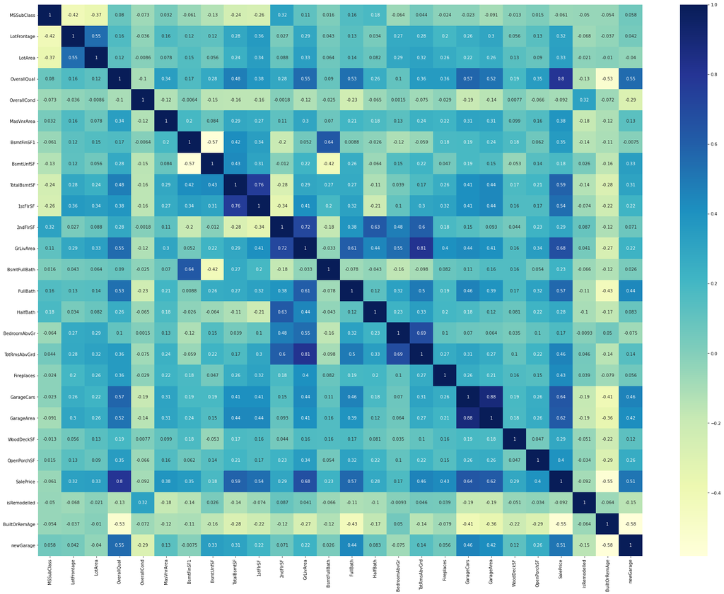

```python
# correlation between the features can be visualised using heatmap
plt.figure(figsize=(32,24))
sns.heatmap(housingData.corr(), cmap="YlGnBu", annot=True)
plt.show()
```

**Inferences**

- `GrLivArea` and `TotRmsAbvGrd` have correlation of 0.81
- `GarageArea` and `GarageCars` have correlation of 0.88

```python
#Dropping TotRmsAbvGrd and GarageArea as they are highly correlated with other predictor variables
housingData.drop(['TotRmsAbvGrd', 'GarageArea'], axis=1, inplace=True)
```

### 2. Data Preparation

```python
housingData.head()
```

|  | MSSubClass | MSZoning | LotFrontage | LotArea | LotShape | LotConfig | Neighborhood | BldgType | HouseStyle | OverallQual | ... | GarageFinish | GarageCars | WoodDeckSF | OpenPorchSF | Fence | SaleCondition | SalePrice | isRemodelled | BuiltOrRemAge | newGarage |
| --- | --- | --- | --- | --- | --- | --- | --- | --- | --- | --- | --- | --- | --- | --- | --- | --- | --- | --- | --- | --- | --- |
| 0 | 60 | RL | 65.0 | 8450 | Reg | Inside | CollgCr | 1Fam | 2Story | 7 | ... | RFn | 2 | 0 | 61 | None | Normal | 208500 | 0 | 5 | 1 |
| 1 | 20 | RL | 80.0 | 9600 | Reg | FR2 | Veenker | 1Fam | 1Story | 6 | ... | RFn | 2 | 298 | 0 | None | Normal | 181500 | 0 | 31 | 0 |
| 2 | 60 | RL | 68.0 | 11250 | IR1 | Inside | CollgCr | 1Fam | 2Story | 7 | ... | RFn | 2 | 0 | 42 | None | Normal | 223500 | 1 | 6 | 1 |
| 3 | 70 | RL | 60.0 | 9550 | IR1 | Corner | Crawfor | 1Fam | 2Story | 7 | ... | Unf | 3 | 0 | 35 | None | Abnorml | 140000 | 1 | 36 | 0 |
| 4 | 60 | RL | 84.0 | 14260 | IR1 | FR2 | NoRidge | 1Fam | 2Story | 8 | ... | RFn | 3 | 192 | 84 | None | Normal | 250000 | 0 | 8 | 1 |

5 rows × 46 columns

```python
#Columns that only needs to be codes(i.e 1,2,3.. for the values)
objCol = list(housingData.select_dtypes(include='object').columns)

#columns that require to have seperate columns for all the unique values
objColTogetDummies = ['MSZoning', 'Neighborhood', 'GarageType', 'Fence', 'Exterior1st', 'Exterior2nd']
objColToCode = [x for x in objCol if x not in objColTogetDummies]
```

```python
for col in objColToCode:
    housingData[col] = housingData[col].astype('category')

#_cd is abbreviation for coded columns
for col in objColToCode:
    housingData[col+"_cd"] = housingData[col].cat.codes
housingData.head()
```

|  | MSSubClass | MSZoning | LotFrontage | LotArea | LotShape | LotConfig | Neighborhood | BldgType | HouseStyle | OverallQual | ... | ExterQual_cd | Foundation_cd | BsmtQual_cd | BsmtExposure_cd | BsmtFinType1_cd | HeatingQC_cd | KitchenQual_cd | FireplaceQu_cd | GarageFinish_cd | SaleCondition_cd |
| --- | --- | --- | --- | --- | --- | --- | --- | --- | --- | --- | --- | --- | --- | --- | --- | --- | --- | --- | --- | --- | --- |
| 0 | 60 | RL | 65.0 | 8450 | Reg | Inside | CollgCr | 1Fam | 2Story | 7 | ... | 2 | 2 | 2 | 3 | 2 | 0 | 2 | 3 | 2 | 4 |
| 1 | 20 | RL | 80.0 | 9600 | Reg | FR2 | Veenker | 1Fam | 1Story | 6 | ... | 3 | 1 | 2 | 1 | 0 | 0 | 3 | 5 | 2 | 4 |
| 2 | 60 | RL | 68.0 | 11250 | IR1 | Inside | CollgCr | 1Fam | 2Story | 7 | ... | 2 | 2 | 2 | 2 | 2 | 0 | 2 | 5 | 2 | 4 |
| 3 | 70 | RL | 60.0 | 9550 | IR1 | Corner | Crawfor | 1Fam | 2Story | 7 | ... | 3 | 0 | 4 | 3 | 0 | 2 | 2 | 2 | 3 | 0 |
| 4 | 60 | RL | 84.0 | 14260 | IR1 | FR2 | NoRidge | 1Fam | 2Story | 8 | ... | 2 | 2 | 2 | 0 | 2 | 0 | 2 | 5 | 2 | 4 |

5 rows × 62 columns

```python
# getDummies for categorical variables
for col in objColTogetDummies:
    housingData = pd.concat([housingData,
                     pd.get_dummies(housingData[col], prefix=col, drop_first=True)],
                     axis=1)
housingData.head()
```

|  | MSSubClass | MSZoning | LotFrontage | LotArea | LotShape | LotConfig | Neighborhood | BldgType | HouseStyle | OverallQual | ... | Exterior2nd_HdBoard | Exterior2nd_ImStucc | Exterior2nd_MetalSd | Exterior2nd_Other | Exterior2nd_Plywood | Exterior2nd_Stone | Exterior2nd_Stucco | Exterior2nd_VinylSd | Exterior2nd_Wd Sdng | Exterior2nd_Wd Shng |
| --- | --- | --- | --- | --- | --- | --- | --- | --- | --- | --- | --- | --- | --- | --- | --- | --- | --- | --- | --- | --- | --- |
| 0 | 60 | RL | 65.0 | 8450 | Reg | Inside | CollgCr | 1Fam | 2Story | 7 | ... | 0 | 0 | 0 | 0 | 0 | 0 | 0 | 1 | 0 | 0 |
| 1 | 20 | RL | 80.0 | 9600 | Reg | FR2 | Veenker | 1Fam | 1Story | 6 | ... | 0 | 0 | 1 | 0 | 0 | 0 | 0 | 0 | 0 | 0 |
| 2 | 60 | RL | 68.0 | 11250 | IR1 | Inside | CollgCr | 1Fam | 2Story | 7 | ... | 0 | 0 | 0 | 0 | 0 | 0 | 0 | 1 | 0 | 0 |
| 3 | 70 | RL | 60.0 | 9550 | IR1 | Corner | Crawfor | 1Fam | 2Story | 7 | ... | 0 | 0 | 0 | 0 | 0 | 0 | 0 | 0 | 0 | 1 |
| 4 | 60 | RL | 84.0 | 14260 | IR1 | FR2 | NoRidge | 1Fam | 2Story | 8 | ... | 0 | 0 | 0 | 0 | 0 | 0 | 0 | 1 | 0 | 0 |

5 rows × 129 columns

```python
#dropping all object type columns from set since those are coded and created dummies
housingData.drop(objCol, axis=1, inplace=True)
housingData.head()
```

|  | MSSubClass | LotFrontage | LotArea | OverallQual | OverallCond | MasVnrArea | BsmtFinSF1 | BsmtUnfSF | TotalBsmtSF | 1stFlrSF | ... | Exterior2nd_HdBoard | Exterior2nd_ImStucc | Exterior2nd_MetalSd | Exterior2nd_Other | Exterior2nd_Plywood | Exterior2nd_Stone | Exterior2nd_Stucco | Exterior2nd_VinylSd | Exterior2nd_Wd Sdng | Exterior2nd_Wd Shng |
| --- | --- | --- | --- | --- | --- | --- | --- | --- | --- | --- | --- | --- | --- | --- | --- | --- | --- | --- | --- | --- | --- |
| 0 | 60 | 65.0 | 8450 | 7 | 5 | 196.0 | 706 | 150 | 856 | 856 | ... | 0 | 0 | 0 | 0 | 0 | 0 | 0 | 1 | 0 | 0 |
| 1 | 20 | 80.0 | 9600 | 6 | 8 | 0.0 | 978 | 284 | 1262 | 1262 | ... | 0 | 0 | 1 | 0 | 0 | 0 | 0 | 0 | 0 | 0 |
| 2 | 60 | 68.0 | 11250 | 7 | 5 | 162.0 | 486 | 434 | 920 | 920 | ... | 0 | 0 | 0 | 0 | 0 | 0 | 0 | 1 | 0 | 0 |
| 3 | 70 | 60.0 | 9550 | 7 | 5 | 0.0 | 216 | 540 | 756 | 961 | ... | 0 | 0 | 0 | 0 | 0 | 0 | 0 | 0 | 0 | 1 |
| 4 | 60 | 84.0 | 14260 | 8 | 5 | 350.0 | 655 | 490 | 1145 | 1145 | ... | 0 | 0 | 0 | 0 | 0 | 0 | 0 | 1 | 0 | 0 |

5 rows × 107 columns

### 3. Train Test Split

```python
from sklearn.model_selection import train_test_split
from sklearn.preprocessing import scale
```

```python
X = housingData.drop(['SalePrice'], axis=1)
y = housingData['SalePrice']
```

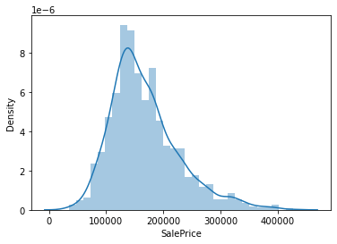

```python
# Check distribution of target variable
sns.distplot(y)
plt.show()
```

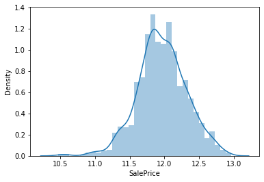

```python
# Correcting the skewness of the target variable
y = np.log(y)
sns.distplot(y)
plt.show()
```